# homework 2

The link to my github repository: [homework 2](https://github.com/snuuym/stats506/tree/main/homework%202)

## Problem 1 Modified Random walk

Consider a 1-dimensional random walk with the following rules:

1. Start at 0.
2. At each step, move +1 or -1 with 50/50 probability.  
   2.1. If +1 is chosen, 5% of the time move +10 instead.  
   2.2. If -1 is chosen, 20% of the time move -3 instead.
3. Repeat steps 2-4 times.(Note that if the +10 is chosen, it’s not +1 then +10, it is just +10.)

Write a function to determine the end position of this random walk.

The input and output should be: Input: The number of steps  
Output: The final position of the walk

### a.

Implement the random walk in these three versions:  
Version 1: using a loop.  
Version 2: using built-in R vectorized functions. (Using no loops.) (Hint: Does the order of steps matter?)  
Version 3: Implement the random walk using one of the “apply” functions.

*Version 1*

```r
#' random_walk1: start at 0, generate walks for n times and return the final position of walk, using the for loop.
#' @param n The number of steps
#'
#' @return The final position of the walk
#' chatgpt taught me to use sample for assigning probability

random_walk1 <- function(n){
  position <- 0
  for(i in 1:n){
    step <- sample(
    x = c(1, -1, 10, -3),     # possible steps
    size = 1,           # draw one value
    replace = TRUE,     # sampling with replacement
    prob = c(0.475, 0.4, 0.025, 0.1)  # probabilities for each outcome
  )
  position <- position + step
  }
  return(position)
}
```

*Version 2*

```r
#' random_walk2: start at 0, generate walks for n times and return the final position of walk, using built-in R vectorized functions.
#' @param n The number of steps
#'
#' @return The final position of the walk

random_walk2 <- function(n){
  steps <- sample(
  x = c(1, -1, 10, -3),     # possible steps
  size = n,           # draw one value
  replace = TRUE,     # sampling with replacement
  prob = c(0.475, 0.4, 0.025, 0.1)  # probabilities for each outcome
  )
  position <- sum(steps)

  return(position)
}
```

*Version 3*

```r
#' random_walk3: start at 0, generate walks for n times and return the final position of walk, using the special apply functiion: replicate
#' @param n The number of steps
#'
#' @return The final position of the walk

#chatgpt told me to use replicate as a simplified special apply method for this question
random_walk3 <- function(n){
  steps <- replicate(n,{
    sample(
      x = c(1, -1, 10, -3),     # possible steps
      size = 1,           # draw one value
      replace = TRUE,     # sampling with replacement
      prob = c(0.475, 0.4, 0.025, 0.1)  # probabilities for each outcome
    )
  })
  position <- sum(steps)

  return(position)
}
```

test case

```r
random_walk1(10)
```

```
[1] 3
```

```r
random_walk2(10)
```

```
[1] 0
```

```r
random_walk3(10)
```

```
[1] 5
```

```r
random_walk1(1000)
```

```
[1] -5
```

```r
random_walk2(1000)
```

```
[1] -26
```

```r
random_walk3(1000)
```

```
[1] 113
```

### b.

Demonstrate that the three versions can give the same result. Show this for both n=10 and n=1000. (You will need to add a way to control the randomization.)

```r
set.seed(123)
random_walk1(10)
```

```
[1] -8
```

```r
set.seed(123)
random_walk2(10)
```

```
[1] -8
```

```r
set.seed(123)
random_walk3(10)
```

```
[1] -8
```

```r
set.seed(123)
random_walk1(1000)
```

```
[1] 41
```

```r
set.seed(123)
random_walk2(1000)
```

```
[1] 41
```

```r
set.seed(123)
random_walk3(1000)
```

```
[1] 41
```

### c.

Use the microbenchmark package to clearly demonstrate the speed of the implementations. Compare performance with a low input (1,000) and a large input (100,000). Discuss the results.

```r
library(microbenchmark)

microbenchmark(
  loop = random_walk1(1000),
  vectorized = random_walk2(1000),
  applyed = random_walk3(1000)
)
```

```
Unit: microseconds
       expr      min       lq       mean    median        uq      max neval cld
       loop 1977.471 2032.903 2168.07057 2069.9055 2135.5670 5000.975   100 a
 vectorized   16.482   17.302   18.24418   18.0605   18.6345   26.117   100  b
    applyed 2250.982 2337.636 2507.42511 2373.3670 2485.5225 3365.403   100   c
```

```r
microbenchmark(
  loop = random_walk1(100000),
  vectorized = random_walk2(100000),
  applyed = random_walk3(100000)
)
```

```
Unit: milliseconds
       expr        min         lq       mean     median         uq        max
       loop 217.797125 228.440807 243.860491 236.123653 251.648816 404.172260
 vectorized   1.455172   1.552137   1.583236   1.586372   1.602095   1.766772
    applyed 252.269392 271.485518 295.382881 284.369850 307.662934 497.887600
 neval cld
   100 a
   100  b
   100   c
```

### Answer:

Whether in low input or large input, vectorized one always performs much better than loop or appplyed method.

### d.

What is the probability that the random walk ends at 0 if the number of steps is 10? 100? 1000? Defend your answers with evidence based upon a Monte Carlo simulation.

```r
n_sim <- 100000
simulations_10 <- replicate(n_sim, random_walk2(10))
prob_10 <- mean(simulations_10==0)
simulations_100 <- replicate(n_sim, random_walk2(100))
prob_100 <- mean(simulations_100==0)
simulations_1000 <- replicate(n_sim, random_walk2(1000))
prob_1000 <- mean(simulations_1000==0)
```

```r
cat("n=10: ",prob_10*100, "% \n", "n=100: ", prob_100*100, "% \n", "n=1000: ", prob_1000*100, "%")
```

```
n=10:  13.275 %
 n=100:  1.893 %
 n=1000:  0.578 %
```

## Problem 2 Mean of Mixture of Distributions

The number of cars passing an intersection is a classic example of a Poisson distribution. At a particular intersection, Poisson is an appropriate distribution most of the time, but during rush hours (hours of 8am and 5pm) the distribution is really normally distributed with a much higher mean.

Using a Monte Carlo simulation, estimate the average number of cars that pass an intersection per day under the following assumptions:

From midnight until 7 AM, the distribution of cars per hour is Poisson with mean 1. From 9am to 4pm, the distribution of cars per hour is Poisson with mean 8. From 6pm to 11pm, the distribution of cars per hour is Poisson with mean 12. During rush hours (8am and 5pm), the distribution of cars per hour is Normal with mean 60 and variance 12 Accomplish this without using any loops.

(Hint: This can be done with extremely minimal code.)

```r
#' car_dist: this function use Monte Carlo simulation to estimate the average number of cars that pass an intersection per day
#' @param n_sim The number of simulations
#'
#' @return The estimated average number of cars that pass an intersection per day

car_dist <- function(n_sim){
  simulations <- replicate(n_sim, {
                          morning <- rpois(n = 8, lambda = 1) #8 hours in the morning that has Poisson distribution
                          day <- rpois(n = 8, lambda = 8) # 8 hours in the daytime that has Posson distribution
                          night <- rpois(n = 6, lambda = 12)
                          rush <- rnorm(n = 2, mean = 60, sd = sqrt(12))
                          total <- sum(morning)+sum(day)+sum(night)+sum(rush)
  }
                )
  return(mean(simulations))
}
```

*Test*

```r
car_dist(100000)
```

```
[1] 264.1177
```

###Answer:  
According to our calculation, the estimation of average number of cars that pass an intersection per day under the following assumptions:264.

## Problem 3

```r
youtube <- read.csv('https://raw.githubusercontent.com/rfordatascience/tidytuesday/master/data/2021/2021-03-02/youtube.csv')
```

### a.

Often in data analysis, we need to de-identify it. This is more important for studies of people, but let’s carry it out here. Remove any column that might uniquely identify a commercial. This includes but isn’t limited to things like brand, any URLs, the YouTube channel, or when it was published.

Report the dimensions of the data after removing these columns.

```r
library(dplyr)
removed_cols = c("brand","superbowl_ads_dot_com_url", "youtube_url", "id", "etag", "published_at", "title","description", "thumbnail", "channel_title")
removed_youtube <- youtube %>% select(-all_of(removed_cols))
dim(removed_youtube)
```

```
[1] 247  15
```

*Answer:* There are 247 rows and 15 columns after de-identifying it.

### b.

For each of the following variables, examine their distribution. Determine whether  
i) The variable could be used as is as the outcome in a linear regression model,  
ii) The variable can use a transformation prior to being used as the outcome in a linear regression model, or  
iii) The variable would not be appropriate to use as the outcome in a linear regression model.

For each variable, report which category it falls in. If it requires a transformation, carry such a transformation out and use that transformation going forward.

View counts  
Like counts  
Dislike counts Favorite counts  
Comment counts  
(Hint: At least the majority of these variables are appropriate to use.)

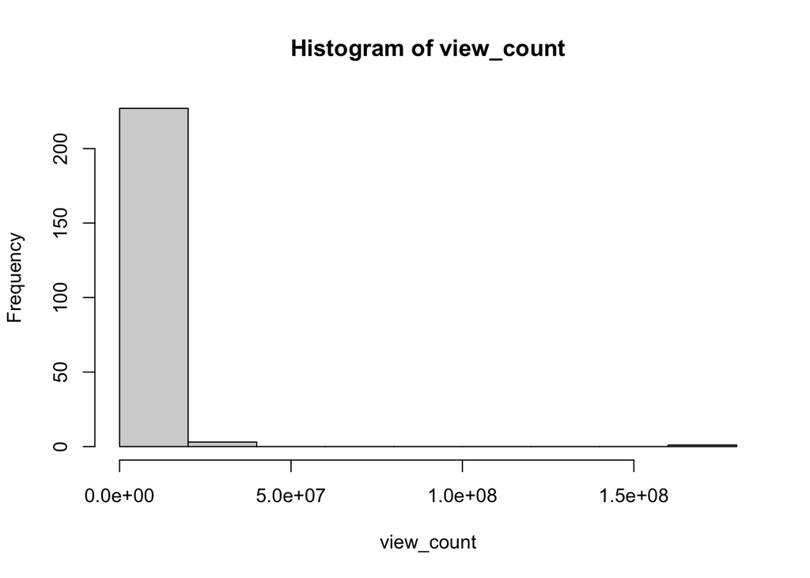

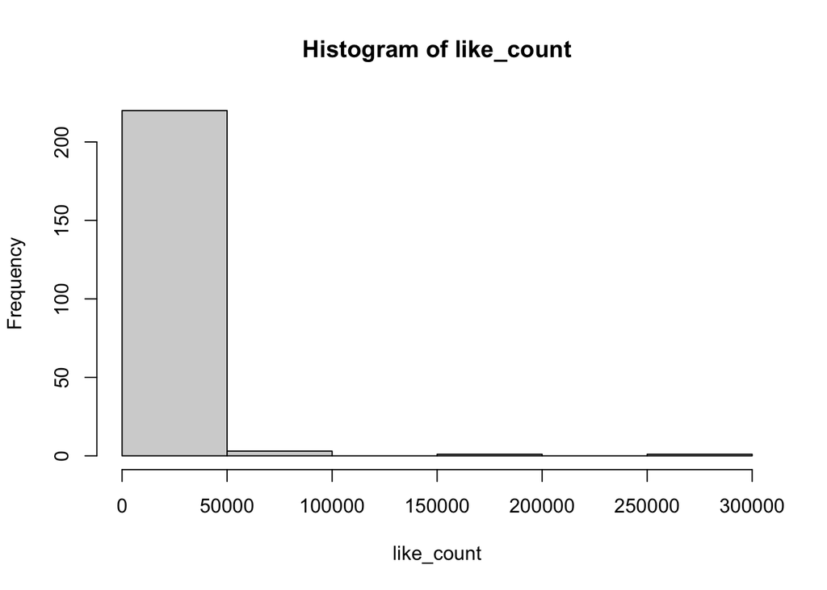

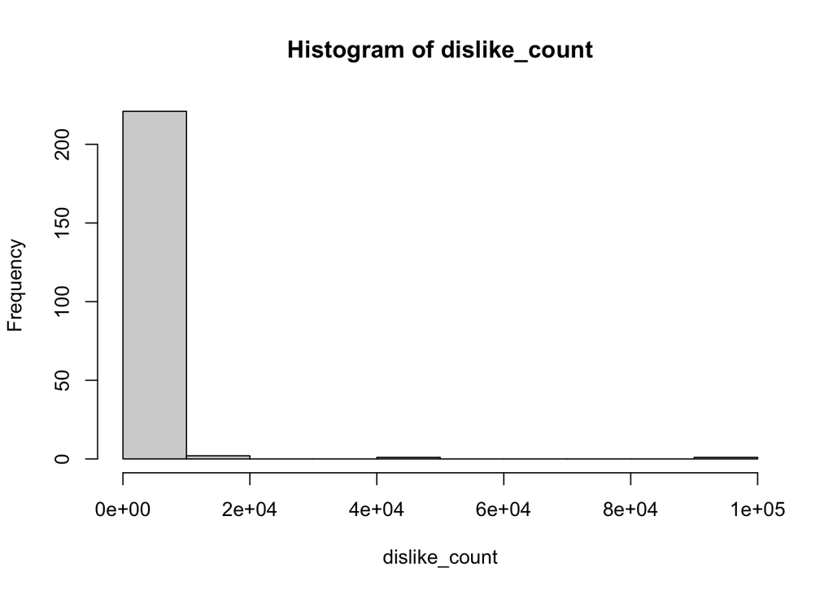

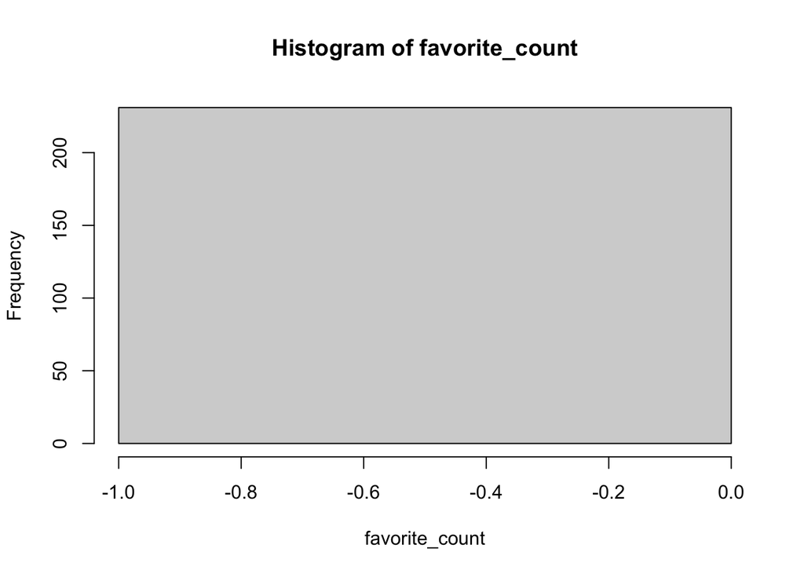

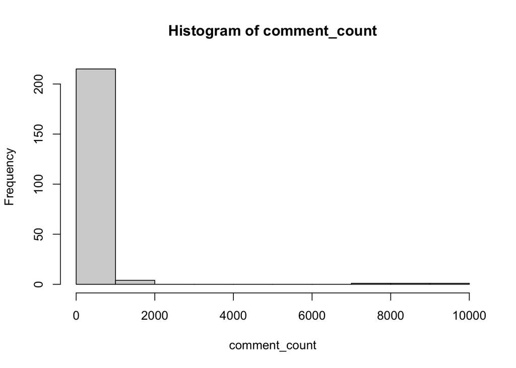

```r
vars <- c("view_count", "like_count", "dislike_count", "favorite_count", "comment_count")

for(var in vars){
  hist(
    removed_youtube[[var]],
    main = paste("Histogram of", var),
    xlab = var
  )
}
```

From the above histgrams we can noe that *Favorite counts* belongs to category (iii), as we cannot see any pattern. For the rest of the variables, let’s make a log transformation to further discuss it.

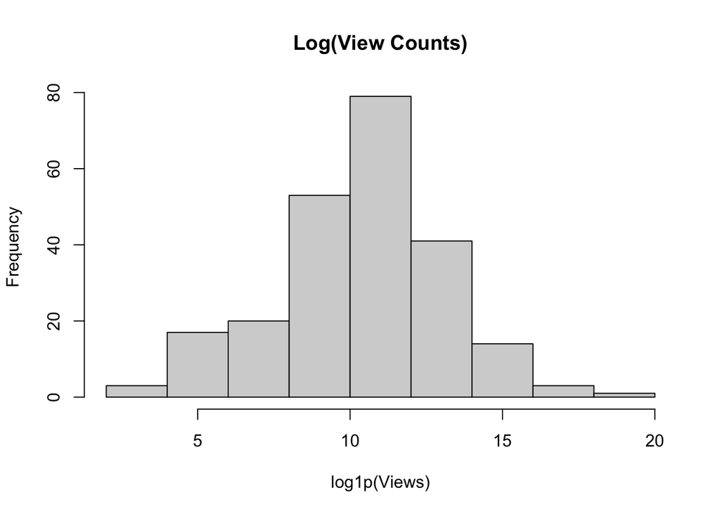

```r
# Transform variables
removed_youtube <- removed_youtube %>%
  mutate(
    log_views     = log1p(view_count),
    log_likes     = log1p(like_count),
    log_dislikes  = log1p(dislike_count),
    log_comments  = log1p(comment_count),
  )

# Check distributions (histograms or density plots)
hist(removed_youtube$log_views, main="Log(View Counts)", xlab="log1p(Views)")
```

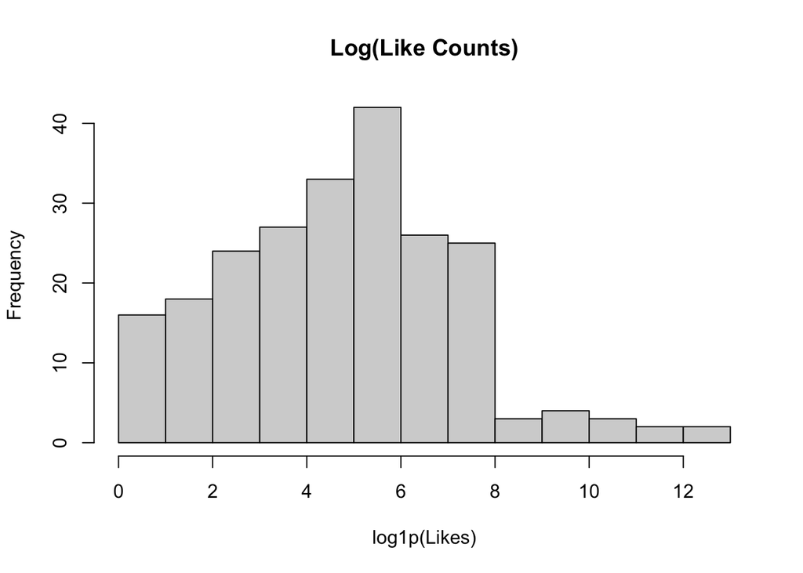

```r
hist(removed_youtube$log_likes, main="Log(Like Counts)", xlab="log1p(Likes)")
```

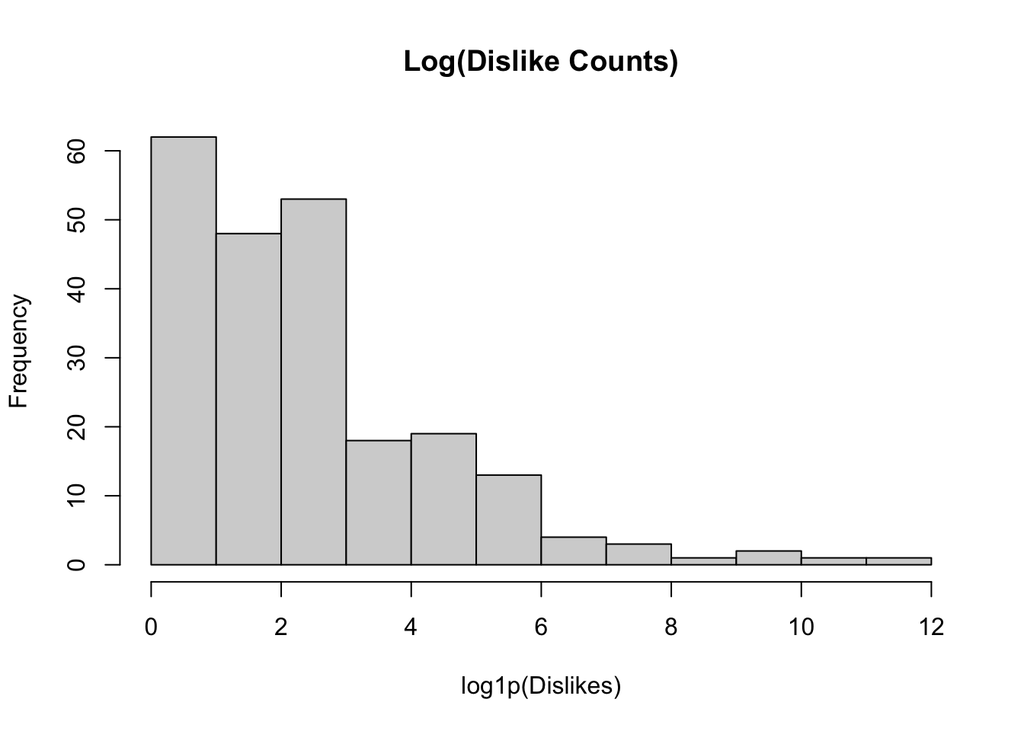

```r
hist(removed_youtube$log_dislikes, main="Log(Dislike Counts)", xlab="log1p(Dislikes)")
```

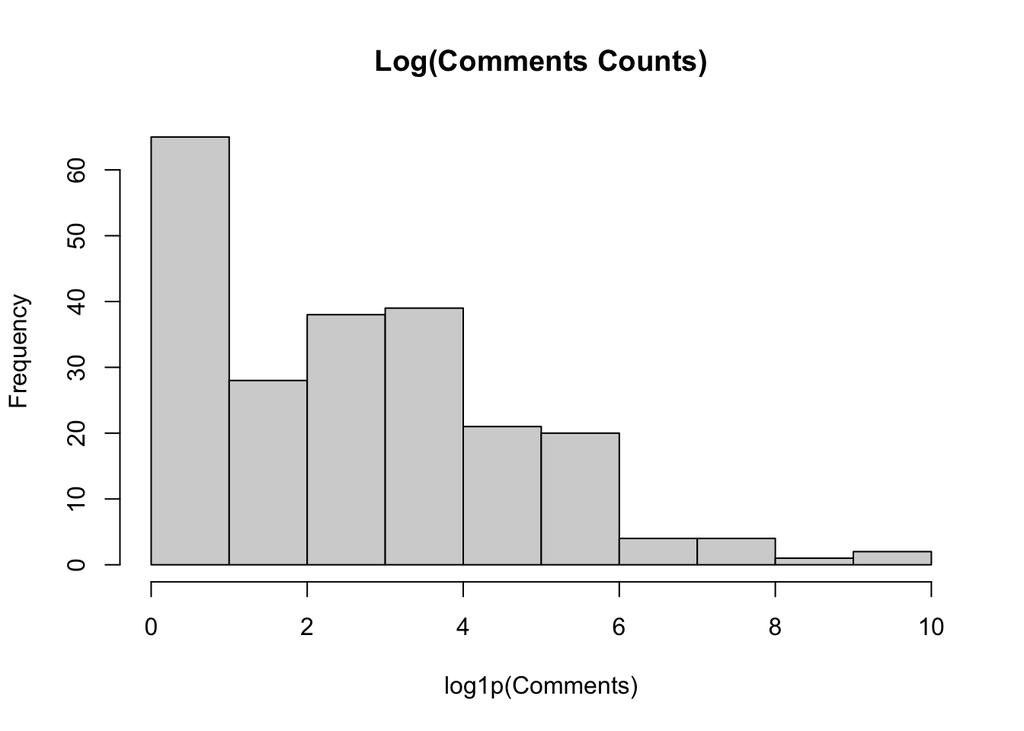

```r
hist(removed_youtube$log_comments, main="Log(Comments Counts)", xlab="log1p(Comments)")
```

All remaining variables shows the some kind of distribution pattern which made them good candidate for linear regression model. So they all belongs to type (ii).

### c.

For each variable in part b. that are appropriate, fit a linear regression model predicting them based upon each of the seven binary flags for characteristics of the ads, such as whether it is funny. Control for year as a continuous covariate.

Discuss the results. Identify the direction of any statistically significant results.

```r
binary_flags <- c("funny", "show_product_quickly", "patriotic", "celebrity", "danger", "animals", "use_sex")
b_vars <- c("log_views", "log_likes", "log_dislikes",  "log_comments")

#chatgpt help me build the dynamical linear regression
for (var in b_vars){
  # Build regression formula dynamically
  f <- as.formula(
    paste(var, "~", paste(c(binary_flags, "year"), collapse = " + "))
  )

  # Fit model
  mod <- lm(f, data = removed_youtube)

  # Print results
  cat("\n=== Model for", var, "===\n")
  print(summary(mod))
}
```

```
=== Model for log_views ===

Call:
lm(formula = f, data = removed_youtube)

Residuals:
    Min      1Q  Median      3Q     Max
-7.7742 -1.6152  0.1311  1.7036  8.4481

Coefficients:
                          Estimate Std. Error t value Pr(>|t|)
(Intercept)              -31.55016   71.00538  -0.444    0.657
funnyTRUE                  0.56492    0.46702   1.210    0.228
show_product_quicklyTRUE   0.21089    0.40530   0.520    0.603
patrioticTRUE              0.50699    0.53811   0.942    0.347
celebrityTRUE              0.03548    0.42228   0.084    0.933
dangerTRUE                 0.63131    0.41812   1.510    0.132
animalsTRUE               -0.31002    0.39348  -0.788    0.432
use_sexTRUE               -0.38671    0.44782  -0.864    0.389
year                       0.02053    0.03531   0.582    0.561

Residual standard error: 2.787 on 222 degrees of freedom
  (16 observations deleted due to missingness)
Multiple R-squared:  0.02694,   Adjusted R-squared:  -0.008122
F-statistic: 0.7684 on 8 and 222 DF,  p-value: 0.631


=== Model for log_likes ===

Call:
lm(formula = f, data = removed_youtube)

Residuals:
    Min      1Q  Median      3Q     Max
-5.2860 -1.6333  0.0868  1.4911  7.7431

Coefficients:
                           Estimate Std. Error t value Pr(>|t|)
(Intercept)              -150.51357   63.45723  -2.372   0.0186 *
funnyTRUE                   0.47476    0.41816   1.135   0.2575
```

[output cut: 57 more lines]

```
funnyTRUE                  0.21954    0.34528   0.636   0.5256
show_product_quicklyTRUE   0.40939    0.30229   1.354   0.1771
patrioticTRUE              0.66698    0.39902   1.672   0.0961 .
celebrityTRUE              0.29767    0.31541   0.944   0.3464
dangerTRUE                 0.17784    0.31069   0.572   0.5677
animalsTRUE               -0.26802    0.29347  -0.913   0.3621
use_sexTRUE               -0.39323    0.33163  -1.186   0.2370
year                       0.05034    0.02632   1.913   0.0571 .
---
Signif. codes:  0 '***' 0.001 '**' 0.01 '*' 0.05 '.' 0.1 ' ' 1

Residual standard error: 2.039 on 213 degrees of freedom
  (25 observations deleted due to missingness)
Multiple R-squared:  0.06535,   Adjusted R-squared:  0.03025
F-statistic: 1.862 on 8 and 213 DF,  p-value: 0.06748
```

*Answer:* From the above regression fit, only log_like and log_dislie variables shows statistical significance as their p-value is less than 0.05. Inside the regression, year is the only statistical significant variable.

### d.

Consider only the outcome of view counts. Calculate $\beta$ manually (without using $lm$) by first creating a proper design matrix, then using matrix algebra to estimate $\beta$ Confirm that you get the same result as $lm$ did in part c.

```r
#clean all the nan in the matrix
removed_youtube <- na.omit(removed_youtube)

f <- as.formula(
  paste("log_views", "~", paste(c(binary_flags, "year"), collapse = " + "))
)

# get the lm model for comparison
lf_mod <- lm(f, data = removed_youtube)

# create the design matrix
des_mat <- model.matrix(f, data = removed_youtube)

y <- removed_youtube$log_views

# using matrix algebra to estimate \beta
beta_hat <- solve(t(des_mat) %*% des_mat) %*% t(des_mat) %*% y
beta_hat <- as.vector(beta_hat)
names(beta_hat) <- names(lf_mod$coefficients)

# Print and compare
print(beta_hat)
```

```
             (Intercept)                funnyTRUE show_product_quicklyTRUE
            -40.95956692               0.75180700               0.26141786
           patrioticTRUE            celebrityTRUE               dangerTRUE
              0.97186446               0.18693308               0.61824418
             animalsTRUE              use_sexTRUE                     year
             -0.05894022              -0.37679568               0.02505906
```

```r
all.equal(beta_hat, lf_mod$coefficients)
```

```
[1] TRUE
```